# Hedemora

Jon Frank

2023-03-23

Hedemora är Dalarnas äldsta stad och fick stadsrättigheter redan på 1400-talet. Idag är arbetsgivare inom vård och omsorg de viktigaste i Hedemora kommun, då ungefär var fjärde förvärvsarbetande arbetar inom denna sektor. Även företag inom tillverkning och utvinning är viktiga, bland annat kopplat till gruvindustrin i Garbenberg.

[figure not shown]

Figur 10

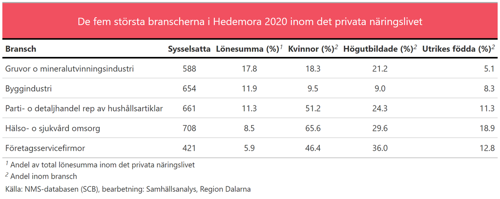

Figur 9

Såväl antal arbetsställen som antal nystartade företag (per 1000 invånare) i Hedemora ligger under genomsnittet i Dalarna. Detsamma gäller antalet konkurser, vilka dessutom har minskat rejält sedan 2013.

Branschbredden i Hedemora är ungefär som genomsnittet i Dalarna och antalet företag var aggregerade lönesummor utgör 50 procent av kommunens lönesumma (i det privata arbetslivet) är i linje med många andra kommuner av samma storlek (20 st). Noterbart är dock att näraliggande Säter är klart mindre beroende, då mer än dubbelt så många företag krävs för att uppnå 50 procent av lönesumman.

Sammanfattningsvis är Hedemora en kommun med viss sårbarhet. Arbetslösheten är en av Dalarnas högsta vilket är en indikation på en arbetsmarkand som skulle kunna få problem vid större kriser/nedläggningar. Hedemora har dock en pendling, ca var tredje som bor i kommunen och arbetar gör det på annan ort, som visserligen är lägre än de största pendlarkommunerna i Dalarna (Säter mfl.), men samtidigt klart högre än i vissa andra kommuner (exempelvis Ludvika och Avesta) vilket är en mildrande faktor vid en eventuell kris/företagsnedläggning.